# Effects of weather events in United States

Coursera.org

### Datascience Specialization - Reproducible Research Course Project #2

*By Pascal Bellerose*

## Synopsis

This project involves exploring the [U.S. National Oceanic and Atmospheric Administration’s (NOAA) storm database](https://d396qusza40orc.cloudfront.net/repdata%2Fdata%2FStormData.csv.bz2). This database tracks characteristics of major storms and weather events in the United States, including when and where they occur, as well as estimates of any fatalities, injuries, and property damage.

The main goal of this research is to figure out which events are the most harmful in terms of population health and economic consequences.

## Data Processing

### Loading of source data

The data for this assignment come in the form of a comma-separated-value file that has been decompressed via the bzip2 algorithm to reduce processing time.

```r
  ## Constants used for file handling
  cstDataFile = "./data/srcStormData"

  bunzip2(paste(cstDataFile, ".bz2", sep=""), cstDataFile, overwrite = TRUE, remove = FALSE)
  dtRaw = fread(cstDataFile,
                   header=TRUE,
                   stringsAsFactors = FALSE,
                   select = c("EVTYPE","FATALITIES","INJURIES","PROPDMG","PROPDMGEXP","CROPDMG","CROPDMGEXP"),
                   na.strings="NA"
               )
```

```
##
Read 67.2% of 967216 rows
Read 902297 rows and 7 (of 37) columns from 0.523 GB file in 00:00:03
```

### Data Preparation

**Some data housekeeping first**

Here are the different values available in the dataset for property and crops damage multipliers.

```
##             -      ?      +      0      1      2      3      4      5
## 465934      1      8      5    216     25     13      4      4     28
##      6      7      8      B      h      H      K      m      M
##      4      5      1     40      1      6 424665      7  11330
```

```
##             ?      0      2      B      k      K      m      M
## 618413      7     19      1      9     21 281832      1   1994
```

Some multipliers were found to be invalid and some others need some case adjustements.  
So we will set them to proper values.

The ones showing `-, +, ?` are going to be resolved to `1` since there are no evidence of what they should be.  
The letters will be converted to proper multipliers.

Let’s start with property damage:

```r
dtTidy$PROPDMGEXP = gsub("h", 100, dtTidy$PROPDMGEXP, ignore.case = TRUE)  ## Hundreds
dtTidy$PROPDMGEXP = gsub("k", 1000, dtTidy$PROPDMGEXP, ignore.case = TRUE)  ## Thousands
dtTidy$PROPDMGEXP = gsub("m", 1e+06, dtTidy$PROPDMGEXP, ignore.case = TRUE)  ## Millions
dtTidy$PROPDMGEXP = gsub("b", 1e+09, dtTidy$PROPDMGEXP, ignore.case = TRUE)  ## Billions
dtTidy$PROPDMGEXP[is.na(as.numeric(dtTidy$PROPDMGEXP))] = 1  ## Special characters and zeros
```

Now let’s convert crops damage multipliers

```r
dtTidy$CROPDMGEXP = gsub("h", 100, dtTidy$CROPDMGEXP, ignore.case = TRUE)  ## Hundreds
dtTidy$CROPDMGEXP = gsub("k", 1000, dtTidy$CROPDMGEXP, ignore.case = TRUE)  ## Thousands
dtTidy$CROPDMGEXP = gsub("m", 1e+06, dtTidy$CROPDMGEXP, ignore.case = TRUE)  ## Millions
dtTidy$CROPDMGEXP = gsub("b", 1e+09, dtTidy$CROPDMGEXP, ignore.case = TRUE)  ## Billions
dtTidy$CROPDMGEXP[is.na(as.numeric(dtTidy$CROPDMGEXP))] = 1  ## Special characters and zeros
```

Multipliers are now cleaned and ready to be used.

```
##      0      1    100   1000  1e+06  1e+09      2      3      4      5
##    216 465973      7 424665  11337     40     13      4      4     28
##      6      7      8
##      4      5      1
```

```
##      0      1   1000  1e+06  1e+09      2
##     19 618420 281853   1995      9      1
```

**Compile damage values**  
We must apply multipliers `PROPDMGEXP` and `CROPDMGEXP` to damage value recorded ‘PROPDMG/CROPDMG’ to get the actual damage caused.

Summary of damage values before we compile:

```r
  summary(dtTidy$PROPDMG)
```

```
##    Min. 1st Qu.  Median    Mean 3rd Qu.    Max.
##    0.00    0.00    0.00   12.06    0.50 5000.00
```

```r
  summary(dtTidy$CROPDMG)
```

```
##    Min. 1st Qu.  Median    Mean 3rd Qu.    Max.
##   0.000   0.000   0.000   1.527   0.000 990.000
```

Compiling values:

```r
  dtTidy$PROPDMG = dtTidy$PROPDMG * as.numeric(dtTidy$PROPDMGEXP)
  dtTidy$CROPDMG = dtTidy$CROPDMG * as.numeric(dtTidy$CROPDMGEXP)
```

Let’s see that summary again…

```
##      Min.   1st Qu.    Median      Mean   3rd Qu.      Max.
## 0.000e+00 0.000e+00 0.000e+00 4.736e+05 5.000e+02 1.150e+11
```

```
##      Min.   1st Qu.    Median      Mean   3rd Qu.      Max.
## 0.000e+00 0.000e+00 0.000e+00 5.442e+04 0.000e+00 5.000e+09
```

**Human Casualties**

As this summary show us, the data seems fairly clean already

Human Fatalities

```
##     Min.  1st Qu.   Median     Mean  3rd Qu.     Max.
##   0.0000   0.0000   0.0000   0.0168   0.0000 583.0000
```

Human Injuries

```
##      Min.   1st Qu.    Median      Mean   3rd Qu.      Max.
##    0.0000    0.0000    0.0000    0.1557    0.0000 1700.0000
```

**Events**

Events can be coded using free text so data had to be cleaned.  
Many entries were doubles using different case or naming. 985 different entries in which many could not be coerced to standard values.

```r
dtTidy$EVTYPE = trim(dtTidy$EVTYPE)
dtTidy[grep("\\?", dtTidy$EVTYPE)] = "NA"
dtTidy$EVTYPE = toupper(dtTidy$EVTYPE)
dtTidy$EVTYPE[startsWith(toupper(dtTidy$EVTYPE), "AVALAN")] = "AVALANCHE"
dtTidy$EVTYPE[startsWith(toupper(dtTidy$EVTYPE), "BEACH ERO")] = "FLOOD"
dtTidy$EVTYPE[startsWith(toupper(dtTidy$EVTYPE), "BLIZZARD")] = "BLIZZARD"
dtTidy$EVTYPE[startsWith(toupper(dtTidy$EVTYPE), "BLOWING SNOW")] = "BLIZZARD"
dtTidy$EVTYPE[startsWith(toupper(dtTidy$EVTYPE), "COASTAL S")] = "STORM SURGE"
dtTidy$EVTYPE[grep("FLOOD", toupper(dtTidy$EVTYPE))] = "FLOOD"
dtTidy$EVTYPE[startsWith(toupper(dtTidy$EVTYPE), "DRY MICROBURST")] = "DRY MICROBURST"
dtTidy$EVTYPE[startsWith(toupper(dtTidy$EVTYPE), "DRY")] = "DROUGHT"
dtTidy$EVTYPE[startsWith(toupper(dtTidy$EVTYPE), "EXCESSIVE COLD") || startsWith(toupper(dtTidy$EVTYPE),
    "EXTREME COLD") || startsWith(toupper(dtTidy$EVTYPE), "EXTENDED COLD")] = "EXTREME COLD"
dtTidy$EVTYPE[grep("WIND.CHILL", toupper(dtTidy$EVTYPE))] = "HIGH WIND"
dtTidy$EVTYPE[startsWith(toupper(dtTidy$EVTYPE), "FREEZING")] = "ICE STORM"
dtTidy$EVTYPE[startsWith(toupper(dtTidy$EVTYPE), "FUNNEL")] = "HIGH WIND"
dtTidy$EVTYPE[startsWith(toupper(dtTidy$EVTYPE), "HAIL")] = "HAIL"
dtTidy$EVTYPE[startsWith(toupper(dtTidy$EVTYPE), "HEAVY SNOW")] = "HEAVY SNOW"
dtTidy$EVTYPE[startsWith(toupper(dtTidy$EVTYPE), "HEAVY RAIN")] = "HEAVY RAIN"
dtTidy$EVTYPE[startsWith(toupper(dtTidy$EVTYPE), "HVY RAIN")] = "HEAVY RAIN"
dtTidy$EVTYPE[startsWith(toupper(dtTidy$EVTYPE), "HIGH WIND")] = "HIGH WIND"
dtTidy$EVTYPE[startsWith(toupper(dtTidy$EVTYPE), "HURRICANE")] = "HURRICANE"
dtTidy$EVTYPE[startsWith(toupper(dtTidy$EVTYPE), "DRY")] = "DROUGHT"
dtTidy$EVTYPE[startsWith(toupper(dtTidy$EVTYPE), "LANDSLIDE")] = "HEAVY RAIN"
dtTidy$EVTYPE[startsWith(toupper(dtTidy$EVTYPE), "LIGHTNING")] = "LIGHTNING"
dtTidy$EVTYPE[startsWith(toupper(dtTidy$EVTYPE), "DRY")] = "DROUGHT"
dtTidy$EVTYPE[startsWith(toupper(dtTidy$EVTYPE), "RAIN")] = "HEAVY RAIN"
dtTidy$EVTYPE[startsWith(toupper(dtTidy$EVTYPE), "PROLONGED RAIN")] = "DROUGHT"
dtTidy$EVTYPE[startsWith(toupper(dtTidy$EVTYPE), "RIP CUR")] = "RIP CURRENTS"
dtTidy$EVTYPE[startsWith(toupper(dtTidy$EVTYPE), "SNOW")] = "HEAVY SNOW"
dtTidy$EVTYPE[startsWith(toupper(dtTidy$EVTYPE), "STRONG WIND")] = "HIGH WIND"
dtTidy$EVTYPE[startsWith(toupper(dtTidy$EVTYPE), "THUNDERSTORM WIND")] = "TSTM WIND"
dtTidy$EVTYPE[grep("TORNADO", toupper(dtTidy$EVTYPE))] = "TORNADO"
dtTidy$EVTYPE[startsWith(toupper(dtTidy$EVTYPE), "TSTM WIND")] = "TSTM WIND"
dtTidy$EVTYPE[startsWith(toupper(dtTidy$EVTYPE), "TROPICAL STORM")] = "TROPICAL STORM"
dtTidy$EVTYPE[startsWith(toupper(dtTidy$EVTYPE), "TORRENTIAL RAIN")] = "HEAVY RAIN"
dtTidy$EVTYPE[startsWith(toupper(dtTidy$EVTYPE), "VOLCANIC")] = "VOLCANIC ASH"
dtTidy$EVTYPE[startsWith(toupper(dtTidy$EVTYPE), "WATERSPOUT")] = "WATERSPOUT"
dtTidy$EVTYPE[startsWith(toupper(dtTidy$EVTYPE), "WIND")] = "HEAVY WIND"
dtTidy$EVTYPE[startsWith(toupper(dtTidy$EVTYPE), "WINTER STORM")] = "WINTER STORM"
dtTidy$EVTYPE[startsWith(toupper(dtTidy$EVTYPE), "WILD")] = "WILD/FOREST FIRE"
dtTidy$EVTYPE[startsWith(toupper(dtTidy$EVTYPE), "WND")] = "HEAVY WIND"
```

The number of different events is now down to 450 entries.

**Now that the data have been cleaned up, we can proceed with data analysis**

## Results

### What weather events are the most harmful with respect to population health?

For this question I need to aggregate the number of casualties — `FATALITIES`, `INJURIES` — by event type `EVTYPE`.

```r
byEvent = group_by(dtTidy, EVTYPE)
topH = summarize(byEvent, Total = sum(FATALITIES + INJURIES, na.rm = TRUE))
topH = arrange(topH, desc(Total))[1:10, ]
```

When drawing a simple Bar chart, it becomes obvious that tornados have the most impact on population health with over 97 000 casualties. Thunderstorm winds come second with a little over 10 000 victims.

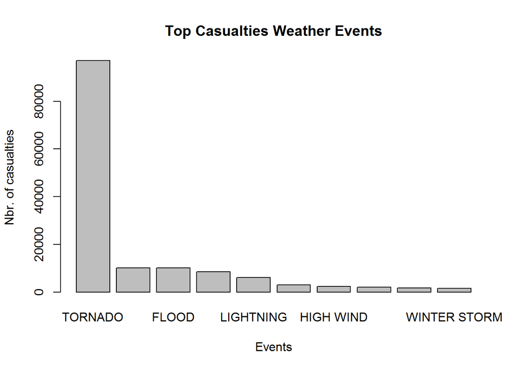

```r
  barplot(topH$Total,
          names = topH$EVTYPE,
          main = "Top Casualties Weather Events",
          xlab="Events",
          ylab="Nbr. of casualties")
```

### What weather events are the most harmful in terms of economic cost of damages?

For this question I need to summarize total cost of damages — `PROPDMG`, `CROPDMG` — by event type `EVTYPE`.

```r
topE = summarize(byEvent, Total = sum(PROPDMG + CROPDMG, na.rm = TRUE))
topE = arrange(topE, desc(Total))[1:10, ]
```

When drawing a simple Bar chart, it becomes obvious that floods are have the greatest economic impact with over 180 B$ in damage recorded. Followed by hurricanes with 90 B$ and tornados with 59 B$

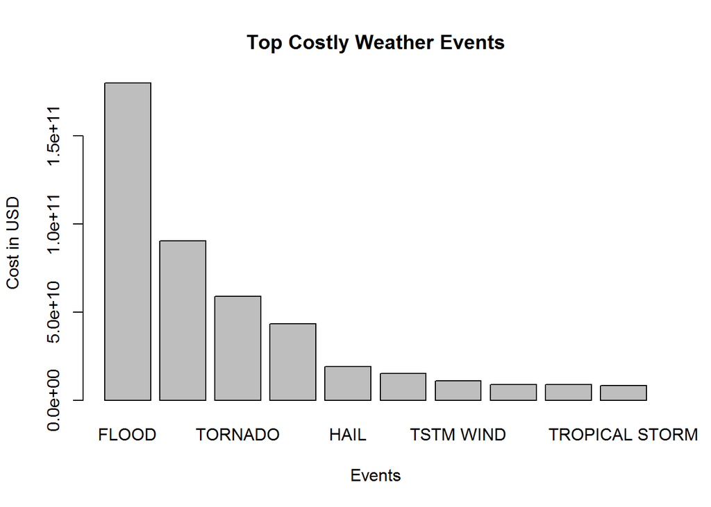

```r
  barplot(topE$Total,
          names = topE$EVTYPE,
          main = "Top Costly Weather Events",
          xlab="Events",
          ylab="Cost in USD")
```